# Resultados Lab 6 - Curso Desembarcando en R

## Ejercicios!

Cargar el set de datos “data/bank.csv”.

```r
library(tidyverse)
library(funModeling)

data_bank=read_delim("../data/bank_2.csv", delim = ";")
```

1 - Crear la variable “positive_balance”, que valga 1 cuando ‘balance > 0’, y el valor 0 cundo balance es negativo.

```r
d1=data_bank %>% mutate(positive_balance=ifelse(balance>0,1,0))
d1
```

```
## # A tibble: 11,162 x 18
##      age job   marital education default balance housing loan  contact
##    <dbl> <chr> <chr>   <chr>     <chr>     <dbl> <chr>   <chr> <chr>
##  1    59 admi… married secondary no         2343 yes     no    unknown
##  2    56 admi… married secondary no           45 no      no    unknown
##  3    41 tech… married secondary no         1270 yes     no    unknown
##  4    55 serv… married secondary no         2476 yes     no    unknown
##  5    54 admi… married tertiary  no          184 no      no    unknown
##  6    42 mana… single  tertiary  no            0 yes     yes   unknown
##  7    56 mana… married tertiary  no          830 yes     yes   unknown
##  8    60 reti… divorc… secondary no          545 yes     no    unknown
##  9    37 tech… married secondary no            1 yes     no    unknown
## 10    28 serv… single  secondary no         5090 yes     no    unknown
## # … with 11,152 more rows, and 9 more variables: day <dbl>, month <chr>,
## #   duration <dbl>, campaign <dbl>, pdays <dbl>, previous <dbl>,
## #   poutcome <chr>, deposit <chr>, positive_balance <dbl>
```

2 - Crear un data frame que tenga la variable balance y positive_balance y verificar si anduvo el procedimiento

```r
d2=d1 %>% select(balance, positive_balance)
d2
```

```
## # A tibble: 11,162 x 2
##    balance positive_balance
##      <dbl>            <dbl>
##  1    2343                1
##  2      45                1
##  3    1270                1
##  4    2476                1
##  5     184                1
##  6       0                0
##  7     830                1
##  8     545                1
##  9       1                1
## 10    5090                1
## # … with 11,152 more rows
```

3 - Ordenar el resultado de 1) por positive_balance y luego por balance importante respetar ese orden… ¿por qué?

```r
d3=arrange(d2, positive_balance, balance)
d3
```

```
## # A tibble: 11,162 x 2
##    balance positive_balance
##      <dbl>            <dbl>
##  1   -6847                0
##  2   -3058                0
##  3   -2712                0
##  4   -2282                0
##  5   -2049                0
##  6   -1965                0
##  7   -1944                0
##  8   -1701                0
##  9   -1636                0
## 10   -1531                0
## # … with 11,152 more rows
```

4a - Remplazar los nulos (creando otra variable) de `contact` por el string “missing”.

```r
d4=data_bank %>% mutate(contact_clean=replace_na(contact, "missing"))
d4
```

```
## # A tibble: 11,162 x 18
##      age job   marital education default balance housing loan  contact
##    <dbl> <chr> <chr>   <chr>     <chr>     <dbl> <chr>   <chr> <chr>
##  1    59 admi… married secondary no         2343 yes     no    unknown
##  2    56 admi… married secondary no           45 no      no    unknown
##  3    41 tech… married secondary no         1270 yes     no    unknown
##  4    55 serv… married secondary no         2476 yes     no    unknown
##  5    54 admi… married tertiary  no          184 no      no    unknown
##  6    42 mana… single  tertiary  no            0 yes     yes   unknown
##  7    56 mana… married tertiary  no          830 yes     yes   unknown
##  8    60 reti… divorc… secondary no          545 yes     no    unknown
##  9    37 tech… married secondary no            1 yes     no    unknown
## 10    28 serv… single  secondary no         5090 yes     no    unknown
## # … with 11,152 more rows, and 9 more variables: day <dbl>, month <chr>,
## #   duration <dbl>, campaign <dbl>, pdays <dbl>, previous <dbl>,
## #   poutcome <chr>, deposit <chr>, contact_clean <chr>
```

4b - Verificar el resultado con freq y/o df_status.

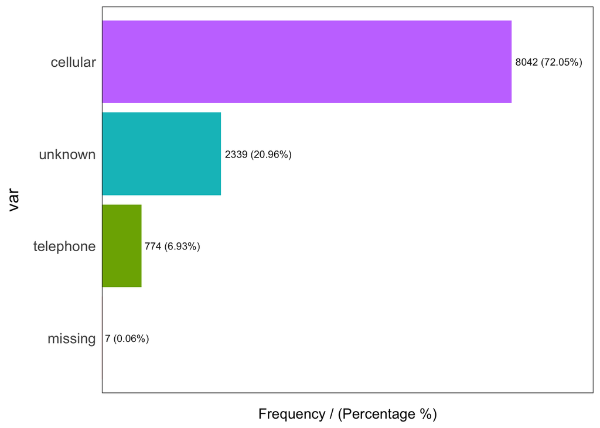

```
##         var frequency percentage cumulative_perc
## 1  cellular      8042      72.05           72.05
## 2   unknown      2339      20.96           93.01
## 3 telephone       774       6.93           99.94
## 4   missing         7       0.06          100.00
```

```r
freq(d4$contact_clean)
```

```r
df_status(select(d4, contact, contact_clean))
```

```
##        variable q_zeros p_zeros q_na p_na q_inf p_inf      type unique
## 1       contact       0       0    7 0.06     0     0 character      3
## 2 contact_clean       0       0    0 0.00     0     0 character      4
```

5a - Crear un data frame que no contenga nulos.

```r
d5=na.omit(data_bank)
```

5b - Verificar cantidad de registros antes y despues

```r
nrow(data_bank)
```

```
## [1] 11162
```

```r
nrow(d5)
```

```
## [1] 11083
```

6 - Crear una variable llamada “jobs_high_share” que tenga el valor “yes” cuando `job` es management, blue-collar o technician. Luego verificar.

```r
v_jobs=c('management', 'blue-collar', 'technician')
d6=mutate(data_bank, jobs_high_share=ifelse(job %in% v_jobs, "yes", "no"))
d6
```

```
## # A tibble: 11,162 x 18
##      age job   marital education default balance housing loan  contact
##    <dbl> <chr> <chr>   <chr>     <chr>     <dbl> <chr>   <chr> <chr>
##  1    59 admi… married secondary no         2343 yes     no    unknown
##  2    56 admi… married secondary no           45 no      no    unknown
##  3    41 tech… married secondary no         1270 yes     no    unknown
##  4    55 serv… married secondary no         2476 yes     no    unknown
##  5    54 admi… married tertiary  no          184 no      no    unknown
##  6    42 mana… single  tertiary  no            0 yes     yes   unknown
##  7    56 mana… married tertiary  no          830 yes     yes   unknown
##  8    60 reti… divorc… secondary no          545 yes     no    unknown
##  9    37 tech… married secondary no            1 yes     no    unknown
## 10    28 serv… single  secondary no         5090 yes     no    unknown
## # … with 11,152 more rows, and 9 more variables: day <dbl>, month <chr>,
## #   duration <dbl>, campaign <dbl>, pdays <dbl>, previous <dbl>,
## #   poutcome <chr>, deposit <chr>, jobs_high_share <chr>
```

7 - La variable marital tiene 3 valores para ‘single’, hacer que solo tenga uno reemplazando todas las variaciones de ‘single’ a un unico valor. Tarea super comun en un proyecto!

RTA: Para mostrar lo versatil de R, aca hay 3 variantes:

```r
# versión 1:
data_bank_v1=data_bank

data_bank_v1$marital[data_bank_v1$marital %in% c('singlee', 'singleee')]='single'
freq(data_bank_v1$marital)
```

```
##        var frequency percentage cumulative_perc
## 1  married      6351      56.90           56.90
## 2   single      3518      31.52           88.42
## 3 divorced      1293      11.58          100.00
```

```r
# versión 2:
data_bank_v2=data_bank
data_bank_v2[data_bank_v2$marital %in% c('singlee', 'singleee'), 'marital']='single'
freq(data_bank_v2$marital)
```

```
##        var frequency percentage cumulative_perc
## 1  married      6351      56.90           56.90
## 2   single      3518      31.52           88.42
## 3 divorced      1293      11.58          100.00
```

```r
# versión 3:
data_bank_v3=data_bank %>% mutate(marital_v3=ifelse(marital %in% c('singlee', 'singleee'), 'single', marital))
freq(data_bank_v3$marital_v3)
```

```
##        var frequency percentage cumulative_perc
## 1  married      6351      56.90           56.90
## 2   single      3518      31.52           88.42
## 3 divorced      1293      11.58          100.00
```